# Determinants of Weekly Working Hours Across Occupations

By Michael Zhao, Max Belykh, Bo Yang,and Huanzhe Zhan

# Introduction and Motivation:

Our goal is to examine how citizenship, gender, occupation, state, and family composition influence working hours, in order to enhance our understanding of participants' labor market behavior. In particular, we are interested in examining how these variables affect the number of hours worked and if specific populations are more inclined to longer or shorter working hours. This issue is set within the global context of contemporary labor markets characterized by the interplay of economic, sociocultural, and political factors that dictate the work – life balance. Dismissing the importance of work hours is economically counterproductive, socially conservative, and regressive. In addition, work hours differ among certain demographic groups due to the availability of employment, family responsibilities, social attitudes toward gender, and immigration rules. Through this analysis, we strive to offer insights for formulating policy geared towards creating discrimination-free laws in the labor market, fostering inclusive workplaces, and making family and career choices. Advances in understanding work participation disparities, workforce policies, and economic equity will require grappling with these dynamics. To substantiate this inquiry are studies of the labor market, employment indicators, and economic theories of social inequality and work-life balance, which help contextualize and validate the findings.

# Literature Review

## Children and Careers: How Family Size Affects Parents’ Labor Market Outcomes in the Long Run

- **Author:** Sara Cools, Simen Markussen, Marte Strom
- **[Link to article](https://pmc.ncbi.nlm.nih.gov/articles/PMC5624987/)**

The correlation between family size and the workforce, mainly weekly hours worked, has received considerable focus. Cools et al. (2017) use instrumental variables to analyze this and demonstrate that family size strongly and negatively affects mothers’ weekly working hours while fathers’ hours remain primarily unchanged. In essence, they argue that each additional child decreases mothers’ labor supply by, on average, 3-5 hours a week, with more pronounced effects during the early years following childbirth and enduring impacts in the scenario of highly educated women. As described, the study illustrates Becker’s well-known economic concepts, a posteriori validation of the econometric assumptions of the Beckerian household model, and a quantity-quality trade-off, which states that an increase in market work necessitated in response to increased childcare duties. Additionally, robust gaps in gender differences in the labor supply perpetuate the maternal employment paradigm, which positions women as principal caregivers. These findings suggest an urgency for more attention to subsidized child care, flexible work hours, active father involvement, and a reduction in the detrimental effects on women’s work hours. The study illustrates the implications of family size on parental participation in the labor market alongside the need for policies on gender inequality in the labor market.

## Gender Inequality, Work Hours, and the Future of Work

- **Authors:** Ariane Hegewisch, M.Phil., and Valerie Lacarte, Ph.D.
- **[Link to report](https://iwpr.org/wp-content/uploads/2020/07/C486_FOW-Work-Hours-Report.pdf)**

The Institute for Women’s Policy Research in 2020 stipulated that there is an unequal allocation of work opportunities to men and women, which in one way or another influences the number of hours each gender is required to work. Women, in most cases, do not work as many hours as men in a week because of an amalgamation of caregiving duties, social norms, and a lack of accepted domestic help, which women have to shoulder alongside their primary work. Women are more likely than men to work shorter hours, not because they want to, but because they are trying to juggle caregiving responsibilities, which decreases their earnings. But it seems men actively take on more full-time and overtime positions that offer set hours. Thus, their earnings increase substantially compared to women's because established practices confirm that subordinate social classes have to work hard to earn good money, and this is especially true in low-paying jobs within the service sector where women are hopelessly trapped.

## Immigration and work schedules: Theory and evidence

- **Authors:** Timothy N. Bond, Osea Giuntella, Jakub Lonsky
- **[Link to report](https://www.sciencedirect.com/science/article/pii/S0014292122002380)**

Regardless of how their weekly employment compares to that of native workers, immigrants are known to work more hours per week, especially during the night. In a study conducted by Bond et al. (2023), it was established that immigrants ‘disproportionately’ fill positions featuring longer or irregular hours because of economic necessity, lower disutility costs, and lack of alternative employment options. Consequently, native workers in regions with higher inflows of immigrant workers tend to receive disproportionate daytime shifts. The reasoning is that immigration to an area causes a decline in compensating differentials for night work. Immigrants tend to accept lower wages and work night shifts, which are undesirable. The study shows that a 10 percentage point increase in the share of immigrants in the workforce decreases the probability of natives working night shifts by 0.8 percentage points and increases wages for daytime shifts. The findings highlight that citizenship status is crucial in allocating work schedules, especially non-citizens, who are overrepresented and fill lower-amenity, extended, or irregular-hours jobs. Even as natives enjoy flexible access to standard work schedules, immigrants are compelled to work longer hours in low-paying, labor-intensive, and monotonous job sectors.

## Map Shows States Where People Are Most Overworked

- **Authors:** Alice Gibbs
- **[Link to article](https://www.newsweek.com/map-shows-states-people-overworked-1966944)**

The Newsweek (2024) article analyzes overwork within U.S. states regarding geography and highlights apparent differences in workload, balance of personal life, and leisure time across regions. Louisiana is labeled as the most overworked state, with an average workweek of 36.5 hours, remote work available at only 6.2%, and a high workplace death rate of 6.4 per 100,000 workers. North Dakota, widely considered the hardest working state, reports a near 98% employment rate alongside a 39.7-hour workweek, with one-third of employees not taking vacation days. Alaska has the highest average workweek at 41.6 hours per week. On average, Americans work more than 1,811 hours a year, more than most developed countries. These observations enhance research on the geography of work about state policies determining overwork, work-life balance, and employee health and welfare.

## Occupation and Working Hours (ATUS 2023)

- **Authors:** Bureau of Labor Statistics
- **[Link to article](https://www.bls.gov/news.release/pdf/atus.pdf)**

The 2023 American Time Use Survey by the U.S. Bureau of Labor Statistics shows variation in working hours by occupation. Construction and extraction workers had the most extended average workday (8.69 hours), followed by production (8.43). Service work was reported to be the shortest at 7.22. Remote work patterns also differed: approximately 49% of management and finance employees worked from home, averaging 5.7 hours remotely, while only 16% of workers in service roles did. Differences by gender also persist; men work 36 minutes more than women daily. These American time-use survey trends show how a person’s occupation and workplace standing elicit differing shifts in the U.S. labor market.

# **Data and Descriptive stats**

```python
# import necessary package
import os
import pandas as pd
import numpy as np
import matplotlib.pyplot as plt
import statsmodels.formula.api as smf
import seaborn as sns
import warnings
from stargazer.stargazer import Stargazer
from IPython.display import display, HTML
# pd.set_option('display.float_format', lambda x: f'{x:g}')

pd.set_option('display.float_format', lambda x: f'{x:f}')
df = pd.read_csv('/Users/maxbelykh/Downloads/usa_data_for_final.csv')
df = df[["UHRSWORK", "OCC", "SEX", "STATEICP","CITIZEN","FAMSIZE","INCWAGE","EDUCD"]]
display(df.describe())
warnings.simplefilter(action='ignore', category=FutureWarning)
```

|  | UHRSWORK | OCC | SEX | STATEICP | CITIZEN | FAMSIZE | INCWAGE | EDUCD |
| --- | --- | --- | --- | --- | --- | --- | --- | --- |
| count | 3405809.000000 | 3405809.000000 | 3405809.000000 | 3405809.000000 | 3405809.000000 | 3405809.000000 | 3405809.000000 | 3405809.000000 |
| mean | 19.463403 | 2438.405749 | 1.509099 | 41.390026 | 0.314384 | 2.995439 | 195020.071619 | 66.566841 |
| std | 21.075620 | 2909.883605 | 0.499917 | 20.876460 | 0.825751 | 1.722640 | 361781.878241 | 32.468125 |
| min | 0.000000 | 0.000000 | 1.000000 | 1.000000 | 0.000000 | 1.000000 | 0.000000 | 1.000000 |
| 25% | 0.000000 | 0.000000 | 1.000000 | 23.000000 | 0.000000 | 2.000000 | 0.000000 | 61.000000 |
| 50% | 8.000000 | 845.000000 | 2.000000 | 44.000000 | 0.000000 | 3.000000 | 27000.000000 | 65.000000 |
| 75% | 40.000000 | 4600.000000 | 2.000000 | 54.000000 | 0.000000 | 4.000000 | 99000.000000 | 101.000000 |
| max | 99.000000 | 9920.000000 | 2.000000 | 98.000000 | 3.000000 | 20.000000 | 999999.000000 | 116.000000 |

### Description of the original data

[output not shown]

### **Data cleaning and modify**

```python
# Exclude invalid data
df = df[~df['STATEICP'].isin([83, 96, 97, 99])]
df = df[df['SEX'] != 9]
df = df[~df['CITIZEN'].isin([0, 8, 9, 5])]
df = df[~df['OCC'].isin([0, 9920])]
df = df[(df["UHRSWORK"] != 0)]
df = df[(df["EDUCD"]!= 999)]
# Rename some data
df.rename(columns={
    "UHRSWORK": "Hours_Worked_Per_Week",
    "OCC": "Occupation",
    "SEX": "Gender",
    "CITIZEN": "Citizenship",
    "FAMSIZE": "Family_Size",
    "EDUCD": "Education_Level",
    "INCWAGE": "Income_Wage",
}, inplace=True)
#For gender, we would make it a dummi variable of been female or not
df["Gender"] = df["Gender"].apply(lambda x: 1 if x == 2 else 0)
#For State we, first convert large states into different regions
state_to_region = {
    # Northeast
    1: "Northeast", 2: "Northeast", 3: "Northeast", 4: "Northeast", 5: "Northeast", 6: "Northeast",
    11: "Northeast", 12: "Northeast", 13: "Northeast", 14: "Northeast",
    # Midwest
    21: "Midwest", 22: "Midwest", 23: "Midwest", 24: "Midwest", 25: "Midwest",
    31: "Midwest", 32: "Midwest", 33: "Midwest", 34: "Midwest", 35: "Midwest", 36: "Midwest", 37: "Midwest",
    # South
    41: "South", 42: "South", 43: "South", 44: "South", 45: "South", 46: "South", 47: "South", 48: "South",
    49: "South", 51: "South", 52: "South", 53: "South", 54: "South", 56: "South",
    # West
    61: "West", 62: "West", 63: "West", 64: "West", 65: "West", 66: "West", 67: "West", 68: "West",
    71: "West", 72: "West", 73: "West", 81: "West", 82: "West"
}
# Map STATEICP to regions
df['Region'] = df['STATEICP'].map(state_to_region)
# Define a mapping of OCC codes to five broad categories
occ_to_category = {
    # Management, Business, Science, and Arts Occupations
    **dict.fromkeys(range(10, 2000), "Management, Business, Science, and Arts"),

    # Service Occupations
    **dict.fromkeys(range(3600, 4700), "Service"),

    # Sales and Office Occupations
    **dict.fromkeys(range(4700, 6000), "Sales and Office"),

    # Natural Resources, Construction, and Maintenance Occupations
    **dict.fromkeys(range(6000, 7700), "Natural Resources, Construction, and Maintenance"),

    # Production, Transportation, and Material Moving Occupations
    **dict.fromkeys(range(7700, 9900), "Production, Transportation,and Material Moving"),

    # Not Applicable or Unemployed
    **dict.fromkeys([0, 9920], "Not Applicable/Unemployed")
}

# Map OCC codes to categories
df['Occupation'] = df['Occupation'].map(occ_to_category)
df["Occupation"] = df["Occupation"].fillna("Not Applicable/Unemployed")

# Do dummi for region
region_dummies = pd.get_dummies(df['Region'], prefix='Region', drop_first=True)
df = pd.concat([df, region_dummies], axis=1)


# Do dummi for occupation
# occupation_dummies = pd.get_dummies(df['Occupation'], prefix='Occupation', drop_first=True)
# df = pd.concat([df, occupation_dummies], axis=1)
# df = pd.concat([df], axis=1)

# change = [col.replace(" ", "_").replace(",", "").replace("-", "_") for col in occupation_dummies.columns]
# occupation_dummies.columns = change
# df = df.drop(columns=change, errors='ignore')
# df = pd.concat([df, occupation_dummies], axis=1)

df["Education_Level"] = df["Education_Level"].astype("object")
def transform_education_level(educ):
    if educ < 62:
        return "No_High_School_Diploma"
    elif 62 <= educ < 101:
        return "High_School_Diploma"
    else:
        return "College_Degree_or_Higher"
df["Education_Level"] = df["Education_Level"].apply(transform_education_level)
```

[output not shown]

The reason why we chose the following variables for the simple regression model is due to the fact that we believe that the variables listed above are crucial and are heavily correlated to the dependent variable (the working hours per week) in reality.

1. Citizenship

Citizenship status is a key socioeconomic indicator that can affect the types of jobs individuals hold and the conditions under which they work. Non-citizens may face fewer job protections and more economic pressure, leading them to accept longer or less flexible work hours. Including this variable allows us to assess how legal and structural factors tied to immigration status shape labor patterns.

2. Gender

Gender is one of the most widely studied dimensions in labor economics, and prior research consistently shows significant differences in work hours between men and women. These disparities often stem from caregiving responsibilities, occupational segregation, and societal expectations. Including gender helps us quantify how these patterns show up in weekly hours worked.

3. Family Size

Family size is a proxy for household responsibilities and financial obligations. Larger families may push individuals to work more hours to meet household needs, although the effect could vary depending on access to childcare, social support, or cultural norms. We include this variable to test whether people with more dependents actually work longer hours.

4. Region

Geographic region affects employment opportunities, job types, and cost of living. For example, labor markets in the South differ from those in the Northeast in terms of job structure, wages, and hours expectations. By including region, we can account for broad structural differences across U.S. labor markets that may influence how much people work.

5. Occupation

Occupation captures the type of work someone does, which directly influences work hours. Some professions (like healthcare, construction, or management) typically demand longer schedules, overtime, or irregular hours. Including occupation helps us control for job-specific effects on work intensity and better isolate the impact of other variables like gender or citizenship.

6. Education

Educational attainment is a strong predictor of labor market outcomes, including job type, stability, and compensation. Individuals with higher levels of education may have access to more flexible or higher-paying jobs, which can affect their weekly working hours. Conversely, those with lower educational attainment may work longer or irregular hours to compensate for lower wages. Including this variable allows us to control for human capital differences and better isolate the effects of other socioeconomic factors like occupation or region.

## Working hours and geography relations

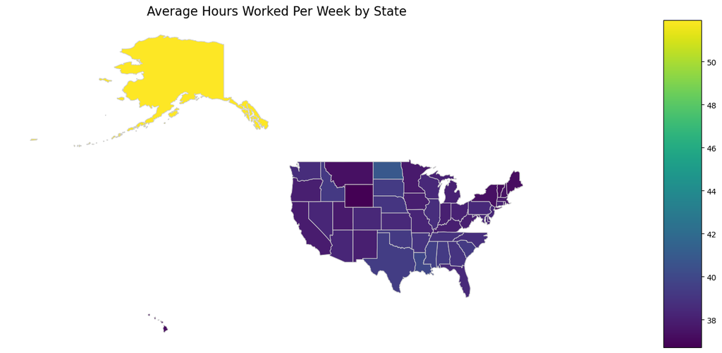

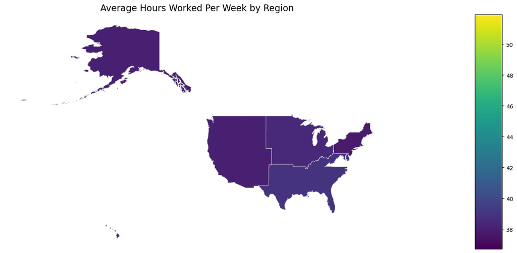

```python
import geopandas as gpd

from mpl_toolkits.axes_grid1 import make_axes_locatable

# Step 1: Load the US map
us_map = gpd.read_file('https://raw.githubusercontent.com/PublicaMundi/MappingAPI/master/data/geojson/us-states.json')

# Step 2: Define STATEICP to state name map
state_labels = {
    1: "Connecticut", 2: "Maine", 3: "Massachusetts", 4: "New Hampshire", 5: "Rhode Island", 6: "Vermont",
    11: "Delaware", 12: "New Jersey", 13: "New York", 14: "Pennsylvania",
    21: "Illinois", 22: "Indiana", 23: "Michigan", 24: "Ohio", 25: "Wisconsin",
    31: "Iowa", 32: "Kansas", 33: "Minnesota", 34: "Missouri", 35: "Nebraska", 36: "North Dakota", 37: "South Dakota",
    41: "Alabama", 42: "Arkansas", 43: "Florida", 44: "Georgia", 45: "Louisiana", 46: "Mississippi",
    47: "North Carolina", 48: "South Carolina", 49: "Texas", 51: "Kentucky", 52: "Maryland", 53: "Oklahoma",
    54: "Tennessee", 56: "West Virginia", 61: "Arizona", 62: "Colorado", 63: "Idaho", 64: "Montana", 65: "Nevada",
    66: "New Mexico", 67: "Utah", 68: "Wyoming", 71: "California", 72: "Oregon", 73: "Washington", 81: "Alaska", 82: "Hawaii"
}

# Step 3: Define Region-to-State mapping
region_to_states = {
    'Northeast': ["Connecticut", "Maine", "Massachusetts", "New Hampshire", "Rhode Island", "Vermont", "New Jersey", "New York", "Pennsylvania"],
    'Midwest': ["Illinois", "Indiana", "Michigan", "Ohio", "Wisconsin", "Iowa", "Kansas", "Minnesota", "Missouri", "Nebraska", "North Dakota", "South Dakota"],
    'South': ["Alabama", "Arkansas", "Delaware", "Florida", "Georgia", "Kentucky", "Louisiana", "Maryland", "Mississippi", "North Carolina", "Oklahoma", "South Carolina", "Tennessee", "Texas", "West Virginia"],
    'West': ["Arizona", "Colorado", "Idaho", "Montana", "Nevada", "New Mexico", "Utah", "Wyoming", "Alaska", "California", "Hawaii", "Oregon", "Washington"]
}
reverse_map = {state: region for region, states in region_to_states.items() for state in states}

# Step 4: Create a new df_map from your existing df, assuming df has STATEICP and Hours_Worked_Per_Week
df_map = df.copy()

# If not already present, add state/region labels
if 'State' not in df_map.columns:
    df_map['State'] = df_map['STATEICP'].map(state_labels)
if 'Region' not in df_map.columns:
    df_map['Region'] = df_map['State'].map(reverse_map)

# Step 5: Compute means
state_hours = df_map.groupby('State')['Hours_Worked_Per_Week'].mean().reset_index()
region_hours = df_map.groupby('Region')['Hours_Worked_Per_Week'].mean().reset_index()

# Step 6: Shared color scale
combined_hours = pd.concat([state_hours['Hours_Worked_Per_Week'], region_hours['Hours_Worked_Per_Week']])
vmin = combined_hours.min()
vmax = combined_hours.max()

# Step 7: Merge and plot state-level map
us_map_states = us_map.merge(state_hours, left_on='name', right_on='State', how='left')

fig, ax = plt.subplots(1, 1, figsize=(15, 10))
divider = make_axes_locatable(ax)
cax = divider.append_axes("right", size="5%", pad=0.1)
us_map_states.plot(column='Hours_Worked_Per_Week', cmap='viridis', linewidth=0.8,
                   ax=ax, edgecolor='0.8', legend=True, cax=cax, vmin=vmin, vmax=vmax)
ax.set_title('Average Hours Worked Per Week by State', fontsize=16)
ax.axis('off')
plt.tight_layout()
plt.show()

# Step 8: Plot region-level map
us_map['Region'] = us_map['name'].map(reverse_map)
us_map_regions = us_map.dissolve(by='Region', as_index=False)
us_map_regions = us_map_regions.merge(region_hours, on='Region', how='left')

fig, ax = plt.subplots(1, 1, figsize=(15, 10))
divider = make_axes_locatable(ax)
cax = divider.append_axes("right", size="5%", pad=0.1)
us_map_regions.plot(column='Hours_Worked_Per_Week', cmap='viridis', linewidth=0.8,
                    ax=ax, edgecolor='0.8', legend=True, cax=cax, vmin=vmin, vmax=vmax)
ax.set_title('Average Hours Worked Per Week by Region', fontsize=16)
ax.axis('off')
plt.tight_layout()
plt.show()
```

## Geographic Differences in Hours Worked

We can see from the graph that for states, Alaska have lot more working hours compare to other states. The overall difference between states are more than in regions. For Regions, northeastern and west work less compare to south and midwest.

- We are using region instead of state for the following reason:
  - It reduces the number of parameters, helping prevent overfitting and preserving degrees of freedom.
  - Regional aggregation captures more stable influences such as shared economic structures, labor market policies, and cultural norms around work.
  - Region-level controls offer a balance between capturing geographic variation and maintaining a parsimonious model.

## Working hours for different occupation

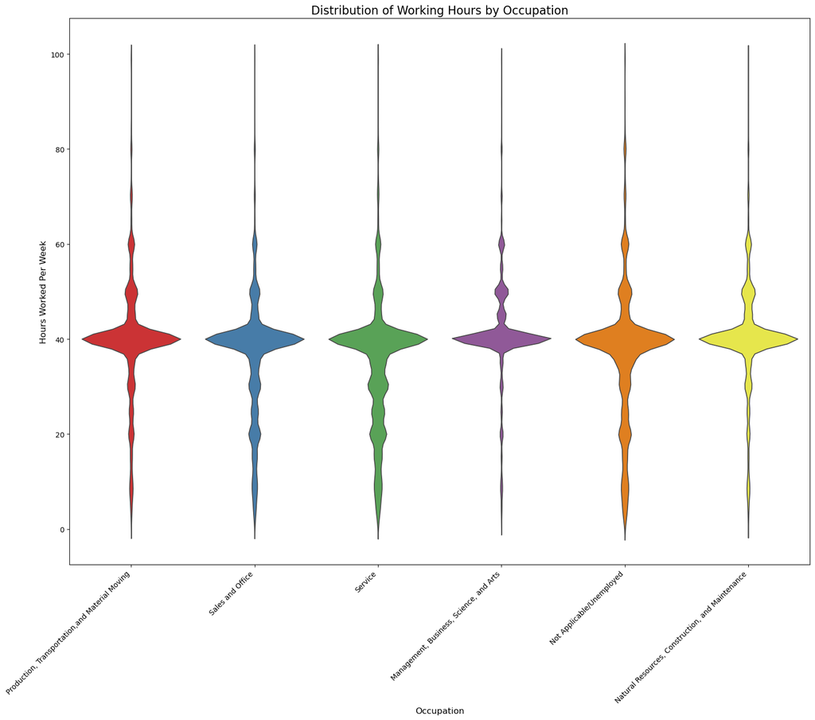

```python
plt.figure(figsize=(16, 14))

sns.violinplot(
    x='Occupation',
    y='Hours_Worked_Per_Week',
    data=df,
    palette='Set1',
    inner=None
)

plt.title('Distribution of Working Hours by Occupation', fontsize=16)
plt.xlabel('Occupation', fontsize=12)
plt.ylabel('Hours Worked Per Week', fontsize=12)
plt.xticks(rotation=45, ha='right')
plt.tight_layout()
plt.show()
```

## Working hours for different educational level

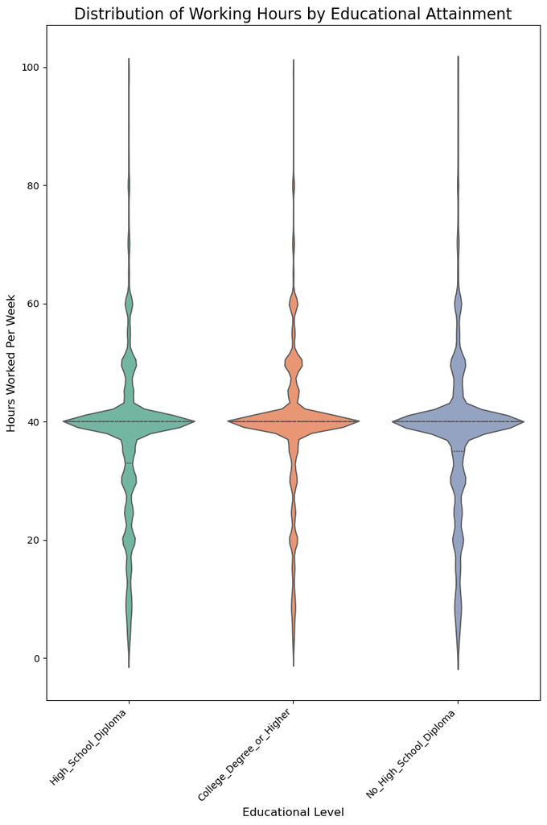

```python
plt.figure(figsize=(8, 12))
sns.violinplot(
    x='Education_Level',
    y='Hours_Worked_Per_Week',
    data=df,
    palette='Set2',
    inner='quartile'
)

# Customize
plt.title('Distribution of Working Hours by Educational Attainment', fontsize=16)
plt.xlabel('Educational Level', fontsize=12)
plt.ylabel('Hours Worked Per Week', fontsize=12)
plt.xticks(rotation=45, ha='right')  # Rotate labels if needed
plt.tight_layout()
plt.show()
```

## Key Predictors of Working Hours: Occupation and Education

The two violin plots above examine how working hours are distributed across occupational categories and education levels.

### Occupation

Occupation captures the structural role an individual plays in the labor market. Different occupations come with different expectations around work hours, job flexibility, and employment contracts. This plot demonstrates that certain groups—like those in service or transportation-related fields—exhibit a wider distribution in hours worked, suggesting a mix of part-time, full-time, and irregular work patterns. Including occupation in the analysis allows the model to account for occupational constraints which have a significant impact on working hours.

### Education

Education level reflects human capital, which influences the type of jobs individuals can access, as well as their income, autonomy, and work schedule stability. The plot shows that individuals with higher education tend to work more predictable hours, while those with lower educational attainment face greater variation, possibly due to informal or precarious employment. This makes education a critical explanatory variable in explaining differences in hours worked across the population.

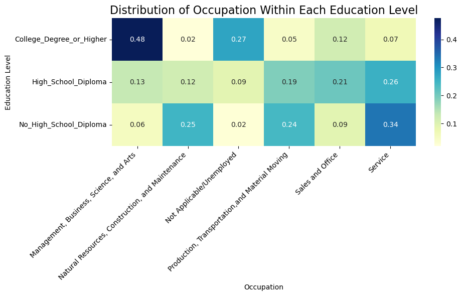

```python
cross_tab = pd.crosstab(df['Education_Level'], df['Occupation'], normalize='index')  # row-wise %

# Plot the heatmap
plt.figure(figsize=(10, 6))
sns.heatmap(cross_tab, annot=True, fmt=".2f", cmap="YlGnBu")

plt.title("Distribution of Occupation Within Each Education Level", fontsize=16)
plt.xlabel("Occupation")
plt.ylabel("Education Level")
plt.xticks(rotation=45, ha='right')
plt.tight_layout()
plt.show()
```

## Education Level and Occupation Association

As we made 2 plots of occupation and education, we know they are two imporatant variables to include, this plot shows the asscociation in between them.

- College Degree or Higher: Over (48%) of individuals in this group are employed in *Management, Business, Science, and Arts*, indicating that higher education is strongly correlated with entry into professional or high-skilled occupations.
- High School Diploma: This group is more evenly distributed across occupations, with a significant share in *Service* (26%) and *Sales and Office* (21%) roles, reflecting a more generalist occupational profile.
- No High School Diploma: The majority of this group are concentrated in *Service* (34%), *Natural Resources, Construction, and Maintenance* (25%), and *Production* (24%), demonstrating a tendency toward manual or lower-skilled jobs.

These finding suggest we check the variance inflation factor to decide if we should exclude one variable to avoid the potential multicollinearity problem.

```python
from statsmodels.stats.outliers_influence import variance_inflation_factor
from patsy import dmatrices

formula = "Hours_Worked_Per_Week ~ C(Education_Level) + C(Occupation) + C(Gender) + C(Region) + C(Citizenship) + Family_Size + Income_Wage"
y, X = dmatrices(formula, data=df, return_type='dataframe')

vif_data = pd.DataFrame()
vif_data["Variable"] = X.columns
vif_data["VIF"] = [variance_inflation_factor(X.values, i) for i in range(X.shape[1])]

print(vif_data.sort_values(by="VIF", ascending=False))
```

```
                                             Variable       VIF
0                                           Intercept 31.931460
13                                C(Citizenship)[T.3]  4.280571
12                                C(Citizenship)[T.2]  4.204426
11                                  C(Region)[T.West]  2.911939
10                                 C(Region)[T.South]  2.869482
9                              C(Region)[T.Northeast]  2.451445
7                            C(Occupation)[T.Service]  1.927120
2        C(Education_Level)[T.No_High_School_Diploma]  1.791679
5   C(Occupation)[T.Production, Transportation,and...  1.707910
3   C(Occupation)[T.Natural Resources, Constructio...  1.672297
1           C(Education_Level)[T.High_School_Diploma]  1.668255
6                   C(Occupation)[T.Sales and Office]  1.562086
4          C(Occupation)[T.Not Applicable/Unemployed]  1.412712
15                                        Income_Wage  1.275108
8                                      C(Gender)[T.1]  1.177783
14                                        Family_Size  1.037735
```

## Multicollinearity Assessment using VIF

Variance Inflation Factors (VIFs) were calculated to assess multicollinearity among the independent variables in the regression model predicting **Hours Worked Per Week**. The results indicate that multicollinearity is not a significant concern.

- Most variables including Education Level and Occupation, have VIFs well below **2.0**, suggesting minimal linear dependence.
- Citizenship status variables have slightly higher VIFs , but still fall below the conventional threshold of **5.0**, indicating acceptable levels of collinearity.

Based on this analysis, **no variables need to be removed** due to multicollinearity. The model is fine.

# Regression model and results (preliminary for proposal just the intuition of the betas and the equation)

$$y=\beta_0 + \beta_1*x_1 + \beta_2*x_2 + \beta_3*x_3 + ... +\beta_n*x_n + \mu$$

## Econometric Model

*Hours_Worked_Per_Week* = β<sub>0</sub> + β<sub>1</sub>*Education_Level* + β<sub>2</sub>*Occupation* + β<sub>3</sub>*Gender* + β<sub>4</sub>*Region* + β<sub>5</sub>*Citizenship* + β<sub>6</sub>*Family_Size*

**Note:** Categorical variables such as *Education_Level*, *Occupation*, *Gender*, *Region*, and *Citizenship* are included as dummy variables in the regression.

```python
# regression=smf.ols(formula = "Hours_Worked_Per_Week ~ Citizenship+Gender+Education_Level+Income_Wage+Family_Size",data= df).fit()
regression_region = smf.ols(
    formula="Hours_Worked_Per_Week ~ Citizenship + Gender + Family_Size + " + " + ".join(region_dummies.columns),
    data=df
).fit()

display(regression_region.summary())
```

OLS Regression Results

| Dep. Variable: | Hours_Worked_Per_Week | R-squared: | 0.030 |
| --- | --- | --- | --- |
| Model: | OLS | Adj. R-squared: | 0.030 |
| Method: | Least Squares | F-statistic: | 1515. |
| Date: | Fri, 25 Apr 2025 | Prob (F-statistic): | 0.00 |
| Time: | 12:48:17 | Log-Likelihood: | -1.1368e+06 |
| No. Observations: | 289223 | AIC: | 2.274e+06 |
| Df Residuals: | 289216 | BIC: | 2.274e+06 |
| Df Model: | 6 |  |  |
| Covariance Type: | nonrobust |  |  |

|  | coef | std err | t | P>\|t\| | [0.025 | 0.975] |
| --- | --- | --- | --- | --- | --- | --- |
| Intercept | 41.4385 | 0.118 | 350.555 | 0.000 | 41.207 | 41.670 |
| Region_Northeast[T.True] | -0.4851 | 0.081 | -5.957 | 0.000 | -0.645 | -0.326 |
| Region_South[T.True] | 0.5548 | 0.075 | 7.349 | 0.000 | 0.407 | 0.703 |
| Region_West[T.True] | -0.3078 | 0.075 | -4.098 | 0.000 | -0.455 | -0.161 |
| Citizenship | -0.4600 | 0.038 | -12.042 | 0.000 | -0.535 | -0.385 |
| Gender | -4.2839 | 0.046 | -93.012 | 0.000 | -4.374 | -4.194 |
| Family_Size | -0.0034 | 0.013 | -0.263 | 0.792 | -0.029 | 0.022 |

| Omnibus: | 19964.070 | Durbin-Watson: | 1.874 |
| --- | --- | --- | --- |
| Prob(Omnibus): | 0.000 | Jarque-Bera (JB): | 103981.694 |
| Skew: | -0.019 | Prob(JB): | 0.00 |
| Kurtosis: | 5.937 | Cond. No. | 28.3 |

Notes:  
[1] Standard Errors assume that the covariance matrix of the errors is correctly specified.

From the model above, we can see that result are more of less out of our expectation (from the negative side). Thus, we decided to introduce other variables and see if it can help with the model to explain more of our observations.

The primary choice that we decide on is the occupation variable. We believe that the occupation variable can decide many specific characteristics relating to the job. And different types of job does hold an important role in determine the wage (economical common sense of specialization).

```python
for i in df["Occupation"].unique():
    df_subset = df[df["Occupation"] == i]
    if not df_subset.empty:
        if(i=="Not Applicable/Unemployed"):
            print(f"The data for this category not applicable, the regression is meaningless but just for reference")
        regression = smf.ols(
            formula="Hours_Worked_Per_Week ~ Citizenship + Gender + Family_Size",
            data=df_subset
        ).fit()

        print(f"Regression for Occupation: {i}:")
        display(regression.summary())
        print("")
    else:
        display(f"No Matched Data for {i}, hence no regression created")
```

```
Regression for Occupation: Production, Transportation,and Material Moving:
```

OLS Regression Results

| Dep. Variable: | Hours_Worked_Per_Week | R-squared: | 0.022 |
| --- | --- | --- | --- |
| Model: | OLS | Adj. R-squared: | 0.022 |
| Method: | Least Squares | F-statistic: | 298.3 |
| Date: | Fri, 25 Apr 2025 | Prob (F-statistic): | 1.57e-191 |
| Time: | 12:48:17 | Log-Likelihood: | -1.5708e+05 |
| No. Observations: | 40155 | AIC: | 3.142e+05 |
| Df Residuals: | 40151 | BIC: | 3.142e+05 |
| Df Model: | 3 |  |  |
| Covariance Type: | nonrobust |  |  |

|  | coef | std err | t | P>\|t\| | [0.025 | 0.975] |
| --- | --- | --- | --- | --- | --- | --- |
| Intercept | 41.5985 | 0.271 | 153.234 | 0.000 | 41.066 | 42.131 |
| Citizenship | -0.0998 | 0.102 | -0.978 | 0.328 | -0.300 | 0.100 |
| Gender | -3.8939 | 0.131 | -29.690 | 0.000 | -4.151 | -3.637 |
| Family_Size | -0.0920 | 0.031 | -2.949 | 0.003 | -0.153 | -0.031 |

| Omnibus: | 3770.104 | Durbin-Watson: | 1.909 |
| --- | --- | --- | --- |
| Prob(Omnibus): | 0.000 | Jarque-Bera (JB): | 24265.006 |
| Skew: | 0.202 | Prob(JB): | 0.00 |
| Kurtosis: | 6.787 | Cond. No. | 22.6 |

Notes:  
[1] Standard Errors assume that the covariance matrix of the errors is correctly specified.

```
Regression for Occupation: Sales and Office:
```

OLS Regression Results

| Dep. Variable: | Hours_Worked_Per_Week | R-squared: | 0.025 |
| --- | --- | --- | --- |
| Model: | OLS | Adj. R-squared: | 0.025 |
| Method: | Least Squares | F-statistic: | 372.1 |
| Date: | Fri, 25 Apr 2025 | Prob (F-statistic): | 1.24e-238 |
| Time: | 12:48:17 | Log-Likelihood: | -1.6973e+05 |
| No. Observations: | 43101 | AIC: | 3.395e+05 |
| Df Residuals: | 43097 | BIC: | 3.395e+05 |
| Df Model: | 3 |  |  |
| Covariance Type: | nonrobust |  |  |

|  | coef | std err | t | P>\|t\| | [0.025 | 0.975] |
| --- | --- | --- | --- | --- | --- | --- |
| Intercept | 39.6966 | 0.266 | 149.210 | 0.000 | 39.175 | 40.218 |
| Citizenship | -0.3462 | 0.100 | -3.466 | 0.001 | -0.542 | -0.150 |
| Gender | -4.0901 | 0.123 | -33.282 | 0.000 | -4.331 | -3.849 |
| Family_Size | 0.0044 | 0.034 | 0.132 | 0.895 | -0.061 | 0.070 |

| Omnibus: | 2354.236 | Durbin-Watson: | 1.898 |
| --- | --- | --- | --- |
| Prob(Omnibus): | 0.000 | Jarque-Bera (JB): | 8290.426 |
| Skew: | -0.180 | Prob(JB): | 0.00 |
| Kurtosis: | 5.118 | Cond. No. | 20.8 |

Notes:  
[1] Standard Errors assume that the covariance matrix of the errors is correctly specified.

```
Regression for Occupation: Service:
```

OLS Regression Results

| Dep. Variable: | Hours_Worked_Per_Week | R-squared: | 0.024 |
| --- | --- | --- | --- |
| Model: | OLS | Adj. R-squared: | 0.024 |
| Method: | Least Squares | F-statistic: | 452.9 |
| Date: | Fri, 25 Apr 2025 | Prob (F-statistic): | 8.99e-291 |
| Time: | 12:48:17 | Log-Likelihood: | -2.2297e+05 |
| No. Observations: | 55541 | AIC: | 4.460e+05 |
| Df Residuals: | 55537 | BIC: | 4.460e+05 |
| Df Model: | 3 |  |  |
| Covariance Type: | nonrobust |  |  |

|  | coef | std err | t | P>\|t\| | [0.025 | 0.975] |
| --- | --- | --- | --- | --- | --- | --- |
| Intercept | 36.6039 | 0.267 | 137.154 | 0.000 | 36.081 | 37.127 |
| Citizenship | 0.3214 | 0.095 | 3.368 | 0.001 | 0.134 | 0.509 |
| Gender | -4.2790 | 0.117 | -36.590 | 0.000 | -4.508 | -4.050 |
| Family_Size | 0.0369 | 0.030 | 1.239 | 0.215 | -0.021 | 0.095 |

| Omnibus: | 3037.931 | Durbin-Watson: | 1.878 |
| --- | --- | --- | --- |
| Prob(Omnibus): | 0.000 | Jarque-Bera (JB): | 9781.907 |
| Skew: | 0.226 | Prob(JB): | 0.00 |
| Kurtosis: | 5.006 | Cond. No. | 23.1 |

Notes:  
[1] Standard Errors assume that the covariance matrix of the errors is correctly specified.

```
Regression for Occupation: Management, Business, Science, and Arts:
```

OLS Regression Results

| Dep. Variable: | Hours_Worked_Per_Week | R-squared: | 0.010 |
| --- | --- | --- | --- |
| Model: | OLS | Adj. R-squared: | 0.010 |
| Method: | Least Squares | F-statistic: | 266.0 |
| Date: | Fri, 25 Apr 2025 | Prob (F-statistic): | 9.06e-172 |
| Time: | 12:48:17 | Log-Likelihood: | -2.8632e+05 |
| No. Observations: | 76235 | AIC: | 5.726e+05 |
| Df Residuals: | 76231 | BIC: | 5.727e+05 |
| Df Model: | 3 |  |  |
| Covariance Type: | nonrobust |  |  |

|  | coef | std err | t | P>\|t\| | [0.025 | 0.975] |
| --- | --- | --- | --- | --- | --- | --- |
| Intercept | 42.4473 | 0.173 | 244.865 | 0.000 | 42.107 | 42.787 |
| Citizenship | -0.4234 | 0.063 | -6.673 | 0.000 | -0.548 | -0.299 |
| Gender | -2.0456 | 0.077 | -26.671 | 0.000 | -2.196 | -1.895 |
| Family_Size | 0.1572 | 0.024 | 6.472 | 0.000 | 0.110 | 0.205 |

| Omnibus: | 9043.943 | Durbin-Watson: | 1.920 |
| --- | --- | --- | --- |
| Prob(Omnibus): | 0.000 | Jarque-Bera (JB): | 98035.923 |
| Skew: | 0.017 | Prob(JB): | 0.00 |
| Kurtosis: | 8.555 | Cond. No. | 20.2 |

Notes:  
[1] Standard Errors assume that the covariance matrix of the errors is correctly specified.

```
The data for this category not applicable, the regression is meaningless but just for reference
Regression for Occupation: Not Applicable/Unemployed:
```

OLS Regression Results

| Dep. Variable: | Hours_Worked_Per_Week | R-squared: | 0.016 |
| --- | --- | --- | --- |
| Model: | OLS | Adj. R-squared: | 0.016 |
| Method: | Least Squares | F-statistic: | 248.2 |
| Date: | Fri, 25 Apr 2025 | Prob (F-statistic): | 9.68e-160 |
| Time: | 12:48:17 | Log-Likelihood: | -1.8233e+05 |
| No. Observations: | 45082 | AIC: | 3.647e+05 |
| Df Residuals: | 45078 | BIC: | 3.647e+05 |
| Df Model: | 3 |  |  |
| Covariance Type: | nonrobust |  |  |

|  | coef | std err | t | P>\|t\| | [0.025 | 0.975] |
| --- | --- | --- | --- | --- | --- | --- |
| Intercept | 41.5099 | 0.304 | 136.736 | 0.000 | 40.915 | 42.105 |
| Citizenship | -1.4450 | 0.113 | -12.826 | 0.000 | -1.666 | -1.224 |
| Gender | -3.2918 | 0.137 | -23.995 | 0.000 | -3.561 | -3.023 |
| Family_Size | 0.2576 | 0.040 | 6.484 | 0.000 | 0.180 | 0.335 |

| Omnibus: | 1992.476 | Durbin-Watson: | 1.919 |
| --- | --- | --- | --- |
| Prob(Omnibus): | 0.000 | Jarque-Bera (JB): | 6903.184 |
| Skew: | 0.026 | Prob(JB): | 0.00 |
| Kurtosis: | 4.916 | Cond. No. | 20.5 |

Notes:  
[1] Standard Errors assume that the covariance matrix of the errors is correctly specified.

```
Regression for Occupation: Natural Resources, Construction, and Maintenance:
```

OLS Regression Results

| Dep. Variable: | Hours_Worked_Per_Week | R-squared: | 0.006 |
| --- | --- | --- | --- |
| Model: | OLS | Adj. R-squared: | 0.006 |
| Method: | Least Squares | F-statistic: | 56.07 |
| Date: | Fri, 25 Apr 2025 | Prob (F-statistic): | 3.95e-36 |
| Time: | 12:48:17 | Log-Likelihood: | -1.1117e+05 |
| No. Observations: | 29109 | AIC: | 2.223e+05 |
| Df Residuals: | 29105 | BIC: | 2.224e+05 |
| Df Model: | 3 |  |  |
| Covariance Type: | nonrobust |  |  |

|  | coef | std err | t | P>\|t\| | [0.025 | 0.975] |
| --- | --- | --- | --- | --- | --- | --- |
| Intercept | 40.8855 | 0.318 | 128.440 | 0.000 | 40.262 | 41.509 |
| Citizenship | 0.1091 | 0.113 | 0.964 | 0.335 | -0.113 | 0.331 |
| Gender | -2.8590 | 0.237 | -12.063 | 0.000 | -3.323 | -2.394 |
| Family_Size | -0.1513 | 0.033 | -4.626 | 0.000 | -0.215 | -0.087 |

| Omnibus: | 3177.231 | Durbin-Watson: | 1.866 |
| --- | --- | --- | --- |
| Prob(Omnibus): | 0.000 | Jarque-Bera (JB): | 28723.402 |
| Skew: | 0.105 | Prob(JB): | 0.00 |
| Kurtosis: | 7.862 | Cond. No. | 25.2 |

Notes:  
[1] Standard Errors assume that the covariance matrix of the errors is correctly specified.

Then we want to add education into our consideration. Of course, seperating it into 3 categories.

```python
education_dummies = pd.get_dummies(df["Education_Level"], prefix="Education_Level", drop_first=True)
df = pd.concat([df, education_dummies], axis=1)

regression_education = smf.ols(
    formula="Hours_Worked_Per_Week ~ Citizenship + Gender + Family_Size + " + " + ".join(education_dummies.columns),
    data=df
).fit()

display(regression_education.summary())
```

OLS Regression Results

| Dep. Variable: | Hours_Worked_Per_Week | R-squared: | 0.037 |
| --- | --- | --- | --- |
| Model: | OLS | Adj. R-squared: | 0.037 |
| Method: | Least Squares | F-statistic: | 2215. |
| Date: | Fri, 25 Apr 2025 | Prob (F-statistic): | 0.00 |
| Time: | 12:48:17 | Log-Likelihood: | -1.1359e+06 |
| No. Observations: | 289223 | AIC: | 2.272e+06 |
| Df Residuals: | 289217 | BIC: | 2.272e+06 |
| Df Model: | 5 |  |  |
| Covariance Type: | nonrobust |  |  |

|  | coef | std err | t | P>\|t\| | [0.025 | 0.975] |
| --- | --- | --- | --- | --- | --- | --- |
| Intercept | 41.9475 | 0.106 | 397.143 | 0.000 | 41.740 | 42.155 |
| Education_Level_High_School_Diploma[T.True] | -2.1269 | 0.051 | -41.932 | 0.000 | -2.226 | -2.027 |
| Education_Level_No_High_School_Diploma[T.True] | -2.4792 | 0.067 | -37.121 | 0.000 | -2.610 | -2.348 |
| Citizenship | -0.2369 | 0.039 | -6.105 | 0.000 | -0.313 | -0.161 |
| Gender | -4.3885 | 0.046 | -95.433 | 0.000 | -4.479 | -4.298 |
| Family_Size | 0.0853 | 0.013 | 6.576 | 0.000 | 0.060 | 0.111 |

| Omnibus: | 20275.226 | Durbin-Watson: | 1.874 |
| --- | --- | --- | --- |
| Prob(Omnibus): | 0.000 | Jarque-Bera (JB): | 107541.190 |
| Skew: | 0.000 | Prob(JB): | 0.00 |
| Kurtosis: | 5.987 | Cond. No. | 21.8 |

Notes:  
[1] Standard Errors assume that the covariance matrix of the errors is correctly specified.

```python
# regressors = ['Citizenship', 'Gender', 'Family_Size'] + region_dummies.columns.tolist() + education_dummies.columns.tolist()
# formula_full = "Hours_Worked_Per_Week ~ " + " + ".join(regressors)

# regression_full = smf.ols(formula=formula_full, data=df).fit()
# display(regression_full.summary())

regressors = ['Citizenship', 'Gender', 'Family_Size'] + region_dummies.columns.tolist() + education_dummies.columns.tolist()
formula_full = "Hours_Worked_Per_Week ~ " + " + ".join(regressors)
regression_models = []
labels = []

for i in df["Occupation"].unique():
    df_subset = df[df["Occupation"] == i]
    if not df_subset.empty:
        if i == "Not Applicable/Unemployed":
            continue

        model = smf.ols(formula=formula_full, data=df_subset).fit()
        regression_models.append(model)
        labels.append(i)

# Generate Stargazer table
stargazer = Stargazer(regression_models)
stargazer.title("OLS Regression by Occupation")
stargazer.custom_columns(labels, [1]*len(labels))

# Display HTML in notebook
display(HTML(stargazer.render_html()))
```

OLS Regression by Occupation

|  | *Dependent variable: Hours_Worked_Per_Week* |  |  |  |  |
| --- | --- | --- | --- | --- | --- |
|  | Production, Transportation,and Material Moving | Sales and Office | Service | Management, Business, Science, and Arts | Natural Resources, Construction, and Maintenance |
|  | (1) | (2) | (3) | (4) | (5) |
| Citizenship | -0.092 | -0.242** | 0.399*** | -0.445*** | 0.198* |
|  | (0.103) | (0.100) | (0.097) | (0.064) | (0.117) |
| Education_Level_High_School_Diploma[T.True] | 0.227 | -1.588*** | -0.662*** | -0.757*** | -0.263 |
|  | (0.182) | (0.131) | (0.167) | (0.094) | (0.246) |
| Education_Level_No_High_School_Diploma[T.True] | -0.014 | -2.895*** | -1.339*** | -0.380* | -0.825*** |
|  | (0.198) | (0.209) | (0.182) | (0.199) | (0.252) |
| Family_Size | -0.083*** | 0.063* | 0.073** | 0.173*** | -0.110*** |
|  | (0.031) | (0.034) | (0.030) | (0.024) | (0.033) |
| Gender | -3.889*** | -4.084*** | -4.319*** | -2.043*** | -2.680*** |
|  | (0.131) | (0.123) | (0.117) | (0.077) | (0.237) |
| Intercept | 41.690*** | 39.455*** | 36.631*** | 42.597*** | 41.839*** |
|  | (0.334) | (0.314) | (0.331) | (0.198) | (0.413) |
| Region_Northeast[T.True] | -1.489*** | 0.333 | 0.094 | -0.018 | -1.888*** |
|  | (0.209) | (0.217) | (0.209) | (0.130) | (0.264) |
| Region_South[T.True] | 0.377** | 1.635*** | 1.311*** | 0.250** | -0.042 |
|  | (0.187) | (0.200) | (0.199) | (0.122) | (0.228) |
| Region_West[T.True] | -0.330* | 1.168*** | 0.073 | -0.156 | -1.554*** |
|  | (0.185) | (0.202) | (0.197) | (0.120) | (0.230) |
| Observations | 40155 | 43101 | 55541 | 76235 | 29109 |
| R<sup>2</sup> | 0.025 | 0.033 | 0.027 | 0.011 | 0.012 |
| Adjusted R<sup>2</sup> | 0.024 | 0.033 | 0.027 | 0.011 | 0.012 |
| Residual Std. Error | 12.080 (df=40146) | 12.369 (df=43092) | 13.387 (df=55532) | 10.343 (df=76226) | 10.991 (df=29100) |
| F Statistic | 126.925*** (df=8; 40146) | 182.961*** (df=8; 43092) | 190.386*** (df=8; 55532) | 110.302*** (df=8; 76226) | 43.769*** (df=8; 29100) |
| Note: | *p<0.1; **p<0.05; ***p<0.01 |  |  |  |  |